# Applied Generalized Linear (Mixed) Modelling

# Model Comparisons

## Variance Explained / F-Test

$R^2 = 1-\frac{var(residual_{full})}{var(residual_{reduced})}$

In order to get the variance explained of the full/reduced model we need to fit the model twice, once with the effect and once without. Conceptually, the test boils down to:

```julia
var1 = var(residuals(lm(@formula(hp ~ 1 + wt), d)))
var0 = var(residuals(lm(@formula(hp ~ 1), d)))
r2 = 1 - var1/var0
```

```
0.6395024519553965
```

## Empirical distribution:

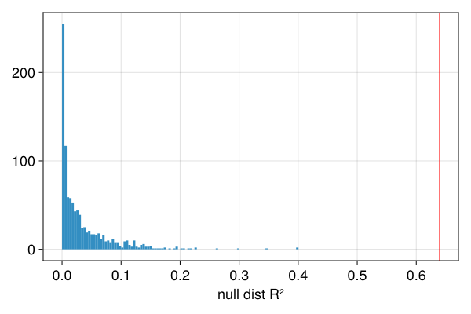

## Analytic solution

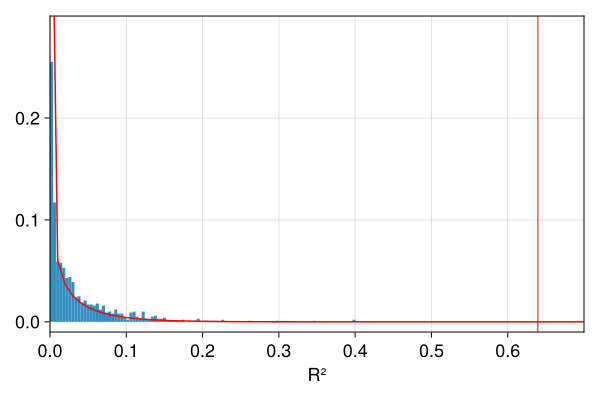

An analytical form is available here as well.

## Usually F-distribution is used

$$F = \frac{\frac{R^2_{m+k}-R^2_{m}}{df_1}}{\frac{1-R^2_{m+k}}{df_2}} = \frac{R^2_{m+k}-R^2_{m}}{1-R^2_{m+k}} * \frac{df_2}{df_1}$$
with bookkeeping (for 1xk ANOVA):

$df_1 = k$, with $k$ the number of predictors

$df_2 = n - m - k -1$, with $n$ the number of observations, $m$ the number of total predictors

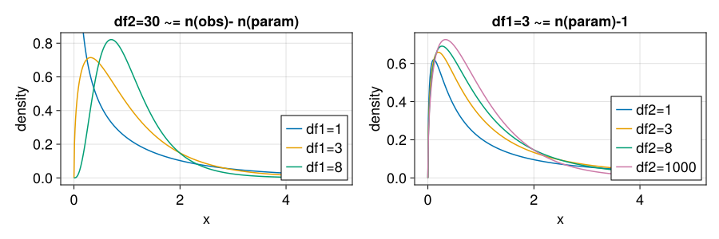

## Overfit

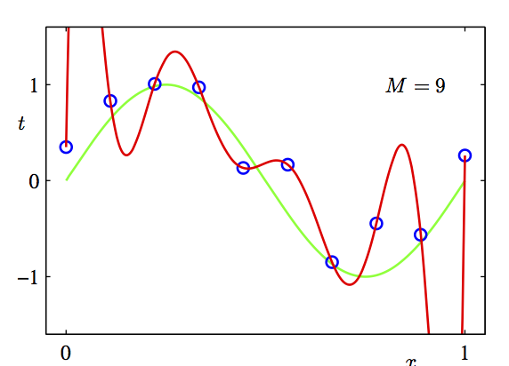

var-explained(predictorA) $<=$ Var-explained(predictorA + predictorB)

Explained-variance is not everything. We also have to take into account the “number” of predictors (or better, the flexibility, or degree of freedoms) we include

## Categorical predictor with multiple levels

Airbnb prices against location in Berlin (first 900 entries)

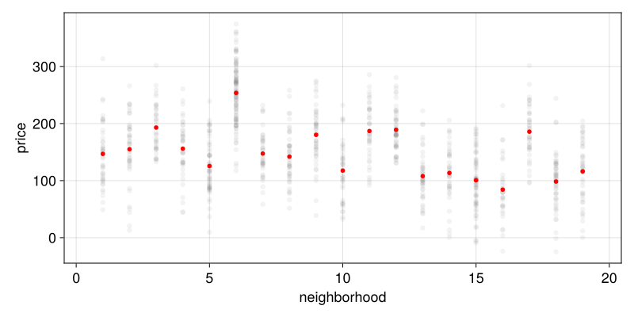